# Spokojenost studentů s dostupností záznamů přednášek na 1.LF UK

Hynek Janáč

hynekjanac@gmail.com

13.04.2026

## Metodika šetření

V březnu 2026 jsem provedl dotazníkové šetření v oblasti spokojenosti studentů se současnou dostupností záznamů přednášek na 1. Lékařské fakultě Univerzity Karlovy.

Dotazník byl rozeslán mezi studenty prostřednictvím kruhových zástupců a studentských skupin na platformě Facebook.

Dotazník vyplnilo celkem **320** studentů.

### Charakteristika respondentů

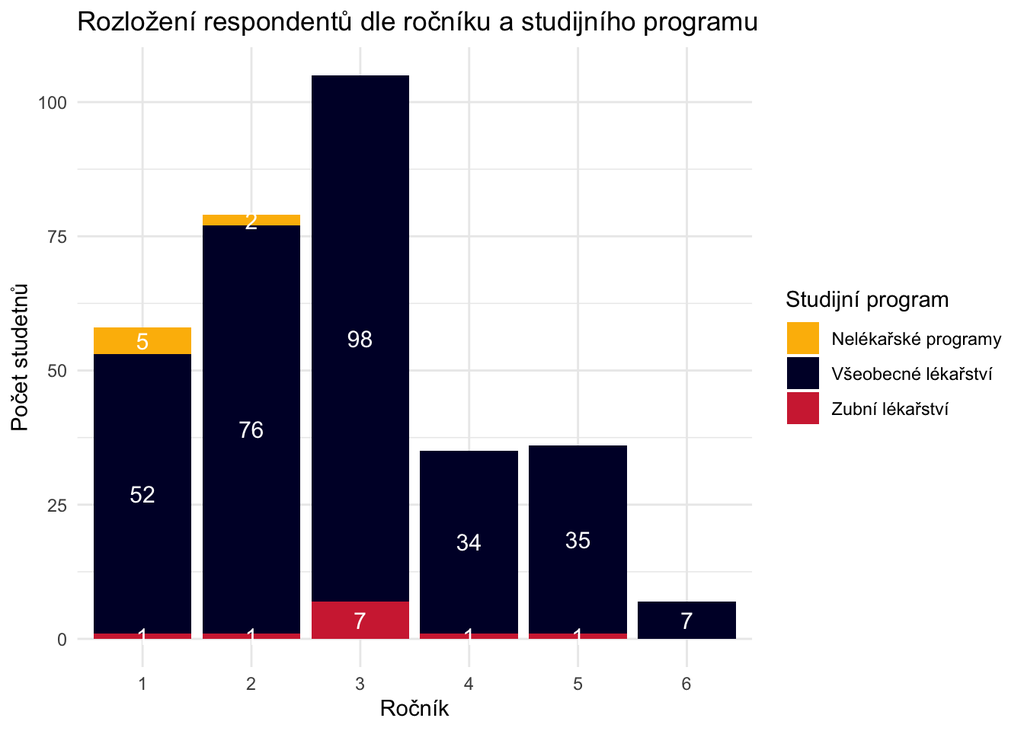

Na dotazník odpovídali převážně studenti studijního programu Všeobecné lékařství napříč ročníky, s největším zastoupením studentů třetího ročníku.

## Souhrn hlavních zjištění

Většina studentů vyjadřuje **zájem** o dostupnost záznamů přednášek. Data ukazují, že záznamy jsou vnímány jako významná pomůcka pro přípravu ke zkouškám a samostudiu.

## Detailní analýza výsledků

Následující části je k dispozici detailní analýza odpovědí na jednotlivé otázky a jejich vzájemné vztahy.

### Frekvence účasti na přednáškách

> **Otázka:** Jak často navštěvujete prezenční přednášky?

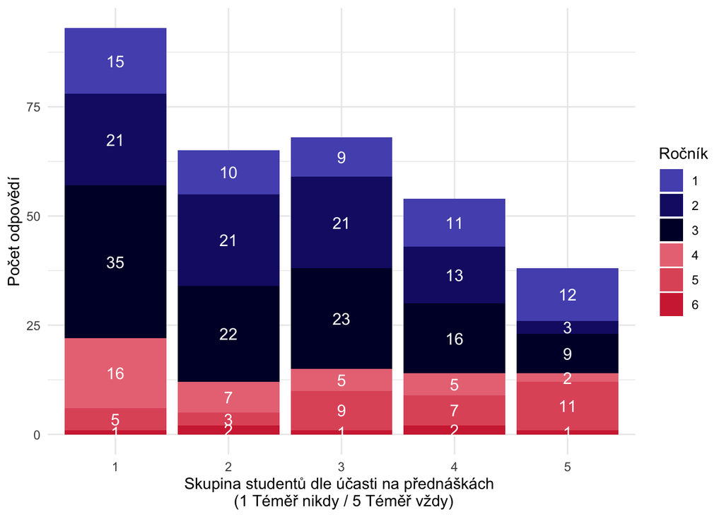

Podle odpovědí na pravidelnost účasti prezenčních přednášek můžeme studenty rozdělit do **5 skupin**. Kdy nejvíce je zastoupena skupina studentů, kteří na prezenční přednášky nedochází téměř nikdy (skupina 1).

Zastoupení jednotlivých skupin je napříč ročníky rovnoměrně rozloženo.

Rozdělení studentů do skupin nám pomůže zasadit další odpovědi do kontextu.

### Faktory ovlivňující účast na přednáškách

> **Otázka:** Co má na Vaše rozhodnutí jít prezenčně na přednášku největší vliv?

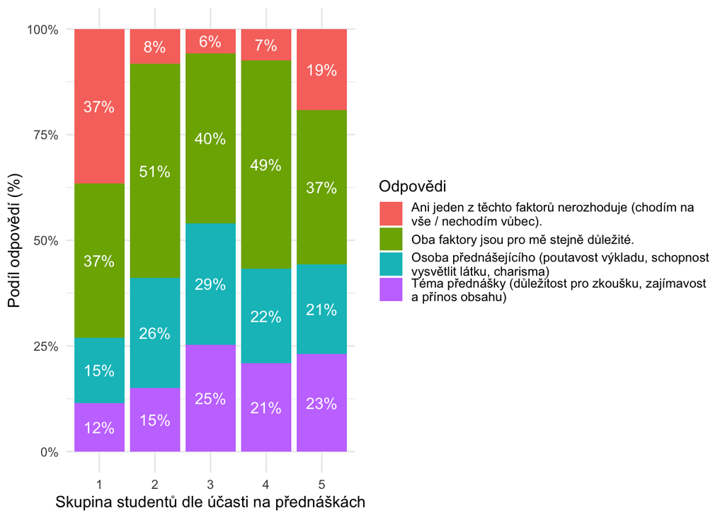

Faktory, které studenti pokládají za nejdůležitější při zvážení prezenční účasti je **kombinace** osoby přednášejícího a témata přednášky, tyto důvody jsou podobné napříč spektrem.

Pro začnou část studentů v 1. skupině (skupina, která téměř nenavštěvuje prezenční přednášky), nehraje roli ani téma přednášky ani osoba přednášejícího.

> **Otázka:** Pokud se rozhodnete nejít na prezenční přednášku, co je nejčastějším důvodem?

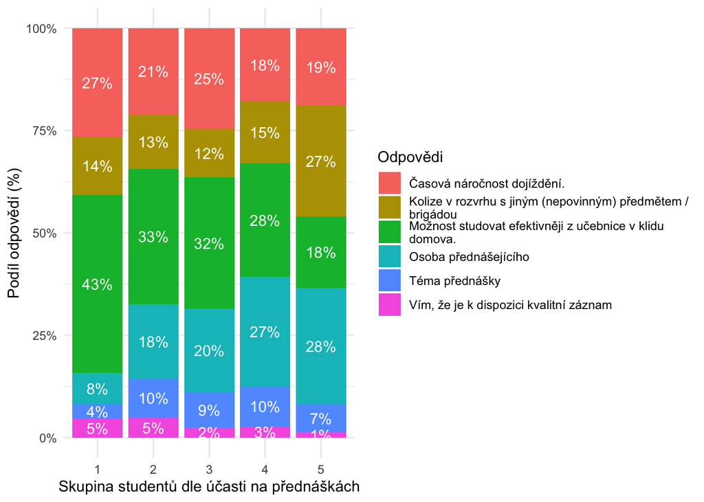

Pro 1. skupinu studentů je nejčastějším důvodem neúčasti na přednášce možnost vlastního **efektivnějšího** studia doma z učebnice.

U dalších skupin tento důvod klesá, ale přetrvávají problémy s dojížděním, či kolize v rozvrhu s dalšími předměty či brigádou.

Zajímavé je, že i pro studenty 5. skupiny (kteří jinak chodí na přednášky téměř vždy) je *osoba přednášejícího* častější příčinou neúčasti, než samotné téma přednášky.

### Vnímaný přínos záznamů pro studium

> **Otázka:** Považujete záznamy přednášek za přínosné pro studium?

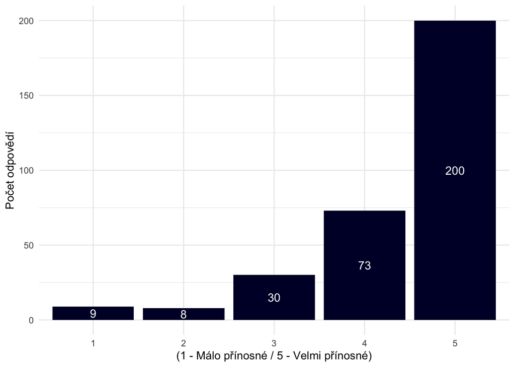

Převážná většina studentů považuje záznamy přednášek jako **přínosné** pro jejich studium.

### Hodnocení současné dostupnosti záznamů

> **Otázka:** Je současná dostupnost záznamů na 1.LF například na MedicalMedia.eu[^1] podle vás dostačující?

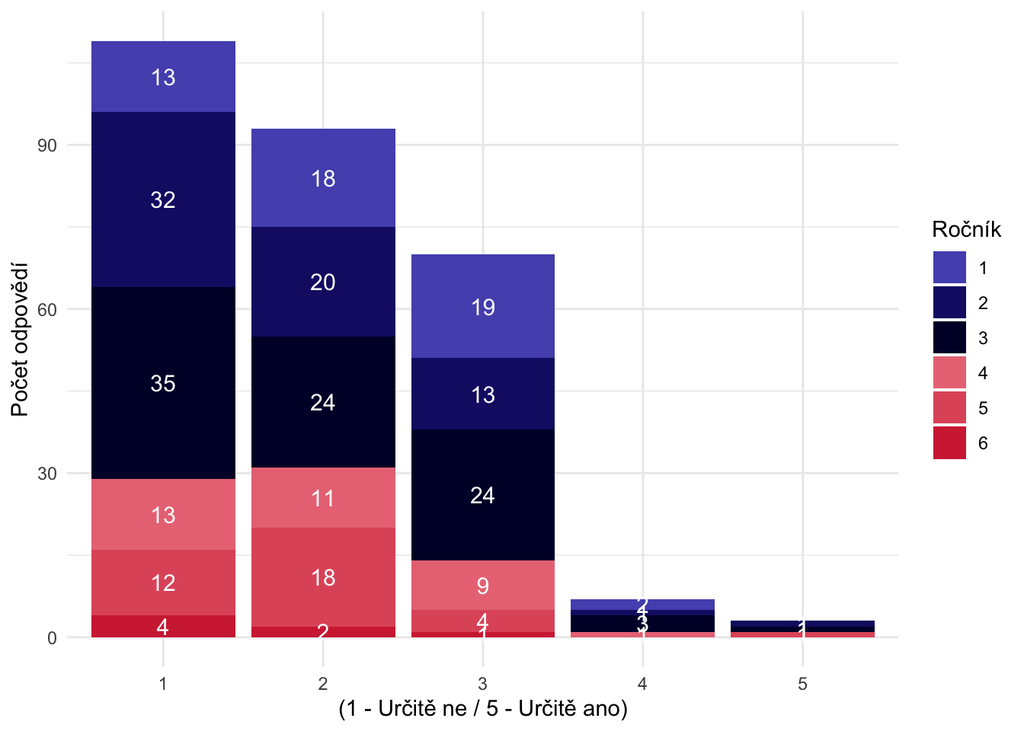

Významné části studentů napříč ročníky připadá současná dostupnost a množství obsahu na fakultním video-portálu **nedostatečná**.

### Role záznamů ve výuce

> **Otázka:** Myslíte si, že by dostupnost záznamů měla být běžnou součástí výuky?

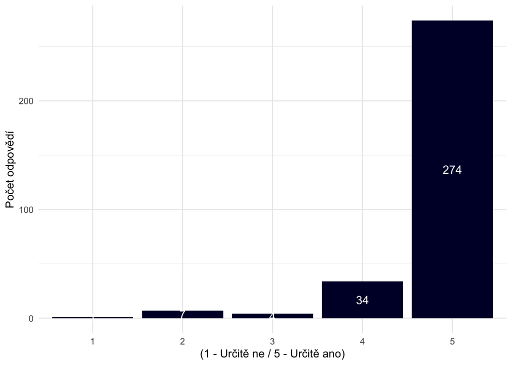

Téměř všichni dotazovaní si myslí, že by záznamy přednášek **měli být součástí** výuky.

### Využití záznamů studenty

> **Otázka:** Pokud byste měli k dispozici záznam, jak byste ho využívali?

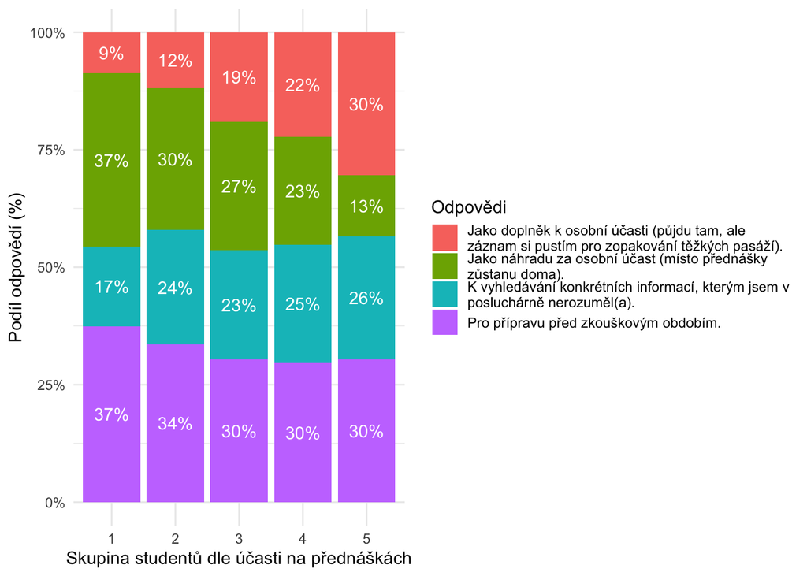

Studenti napříč skupinami udávají ve srovnatelném zastoupení, že by záznamy využívali při přípravě před nadcházejícími zkouškami.

Skupina, která na přednášky nedochází by záznamy využila k samostudiu.

### Vliv dostupnosti záznamů na účast na přednáškách

> **Otázka:** Myslím si, že pokud by byly záznamy dostupné, chodil(a) bych na přednášky méně často.

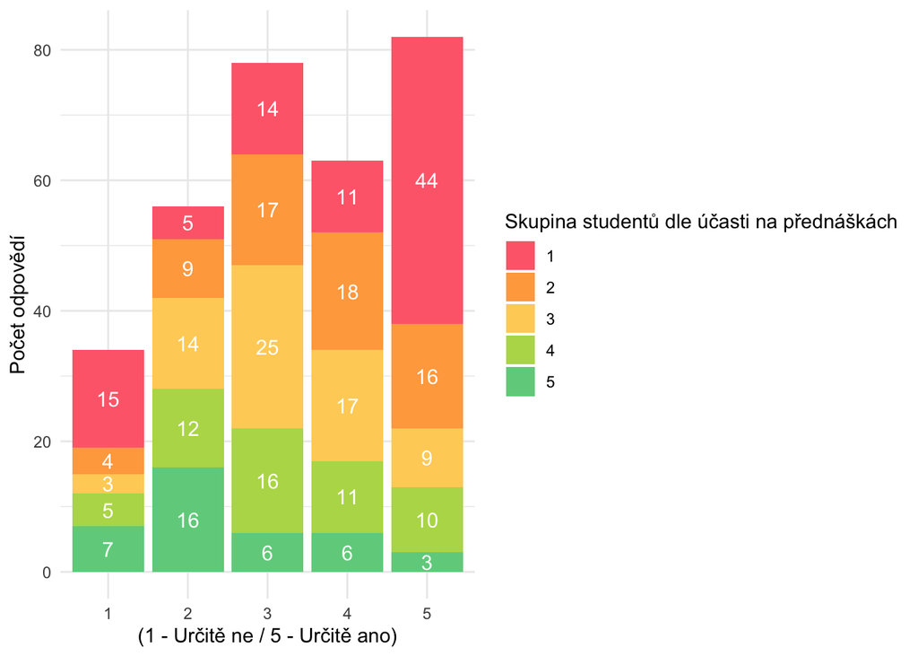

### Kvalitativní zpětná vazba studentů

Poslední sekce dotazníku byla otevřena volným komentářům od studentů. Zde je několik vybraných postřehů.

> Příkladem toho, jak má vypadat výuka, je jednoznačně **gynekologie v 6. ročníku**. Záznamy z přednášek mi strašně moc pomohly se na státnici připravit. Sedět v posluchárně mi nedává vůbec nic, takže ta možnost si to pustit a v klidu si udělat doma výpisek je pro mě osobně velmi dobrá varianta - *student 6. ročníku*

> Záznamy by byly super, někdy nevydržím dávat 100% pozornost po celou přednášku a některé principy slyšet dvakrát by určitě také neuškodilo - *student 5. ročníku*

> Video přednášky jsou pro mě největším zdrojem protože nejlépe se mi učí audiovizuálně , mrzí mě že u nás máme videí málo a ve špatné kvalitě , na druhou stranu chválím pana doktora Jaromíra Šrámka který provozuje youtube kanál a vše poctivě přidává - *student 1. ročníku*

> Já jsem hodně zaneprázdněný člověk a je pro mě každá minuta drahá. Některé přednášky jsou skvělé, ale i přesto je pro mě mnohem efektivnější si k tomu sama sednout - je to rychlejší. Bylo by ale skvělé, kdyby byly dostupné záznamy ze všech přednášek. Takhle si to můžu hodit do pozadí do sluchátek současně při výkonu i něčeho jiného (což dělám i teď) a zároveň to jde taky i zrychlit. - *studentka 3. ročníku*

> Bohužel si z přednášek, které proběhly např. v říjnu, v červnu opravdu nic nepamatuju. Proto pro mě přednášky jako takové význam nemají a nechodím tam. Raději si pak pustím při přípravě na zkoušku přednášku z jiné fakulty nebo video anglické, díky čemuž lépe porozumím dané látce. Nahrávané přednášky bych tak velmi ocenila. - *student 3. ročníku*

> Na právnické fakultě funguje tento systém už dlouho, kdo chce prijde, kdo nechce ma přednášku nahranou online, nekdy se vysílá přednáška i live z posluchárny. V teto době mi přijde šílené že doktoři chodí vykládat kazdy týden stejne téma pořád dokola kdyz by se to dalo jednoduše zveřejnit online - *student 4. ročníku*

> Velmi často se mi stává že na přednášce přehlídnu, nebo něčemu neporozumím a vždy si říkám kdy by byl nějaký záznam na kterém si to mohu projet znovu. - *student 2. ročníku*

> Přednášky navštěvuji zejména z důvodu povinné prezence na nich. Bylo by přínosem mít možnost studovat z domova a do školy dojíždět pouze na stáže. - *student 5. ročníku*

> My teď máme většinu přednášek povinných, ale i zak by to byl super nástroj, pokud by se k tomu chtěl člověk vrátit - *student 5. ročníku*

> V dnešní době nechápu, že nemáme přednášky v elektronické formě. Pustit si přednášku kdekoliv na rychlost x2 je bare minimum, které bych očekávala. V klidu si můžu zapsat, co potřebuju, dogooglit věci, co nechápu, nebo nějaký širší kontext a nestane se mi, že bych nestíhala dál. Fyzické přednášky jsem vzdala, absolutně mi to nevyhovuje, nevydržím prostě jen sedět a poslouchat a vše pobrat. Nebo naopak přeskočit části, co už znám. A hlavně to mít na již zmíněnou rychlost x2. Myslím, že minimálně pro 1.-3. ročník je to víc než jednodušší zařídit studentům nahrávky nebo aspoň online připojení. - *student 4. ročníku*

## Závěry a doporučení

Výsledky dotazníku ukazují na výraznou **nespokojenost** studentů napříč skupinami s nedostupností záznamů přednášek a na jejich **silný zájem** o ně.

Většina studentů uvádí, že by jim dostupné video-přednášky pomohly při přípravě na zkoušky, ulehčily by jim problémy s dojížděním a využívali je k zopakování témat, která dělají problém.

### Potenciální výhody záznamů přednášek

Záznamy by umožnily šíření informací širšímu okruhu studentů, tedy i těm, kteří by se prezenční přednášky nezúčastnili.

Dále by záznamy vytvořily rezervu pro případy, kdy se výuka nemůže uskutečnit (např. nemoc přednášejícího, státní svátek či rektorské/děkanské volno).

Záznamy by také umožnily studentům ve vyšších ročnících vracet se k dříve probíraným tématům a naopak motivovaným studentům z nižších ročníků prohlubovat porozumění dané problematice, čímž by podpořily self-directed learning a hrály by důležitou roli ve spirálním kurikulu.

Další potenciální výhodou již vytvořené videobanky záznamů by bylo snížení rizika pro vyučující experimentovat s aktivizačními metodami výuky. Role vyučujícího jako zdroje informací by tak byla zčásti pojištěna v minulých záznamech.

### Potenciální problémy

Na začátku by problém mohl spočívat ve zvýšených technických nárocích na vyučující, ale vyškolení (často již přítomného) technického pracovníka by nemělo být náročné.[^2]

Jedním z problémů je potenciální neaktuálnost informací starších záznamů, či případné chyby v přednáškách. Řešení tohoto problému spočívá v postupné aktualizaci záznamů.

Problém zabezpečení přístupu k videím je ošetřen nástroji platformy MedicalMedia, ta umožňuje omezit přehrávání videí pouze studentům Univerzity Karlovy, blokuje stahování a další neoprávněné nakládání s videomateriály.[^4]

### Závěrečné doporučení implementace záznamů přednášek do výuky

Doporučuji využít záznamy, které vznikly během distanční výuky a jejich umístění na fakultní platformu MedicalMedia.eu, které poskytuje dostatečné zabezpečení a organizační funkce. Klíčové by následně bylo správné zařazení videí do playlistů a pod kanály jednotlivých ústavů.

Domnívám se, že dostupnost e-learnigových video-materiálů, pomůže s modernizací výuky a dodá vyučujícím prostor k experimentování v jiných oblastech vzdělávacího procesu.

#### Další postup

1. Vytipovat přednášky, které výrazně zastaraly a opatřit je varováním a případně se připravit na nahrání aktualizované verze.
2. Následující akademický rok, připravit technické vybavení poslucháren (většina hlavních poslucháren již požadavky splňuje): mikrofon a software na pořízení záznamu obrazovky.
3. Nově nahrané přednášky opět nahrát na MedicalMedia správně zařadit.

## Limity dotazníkového šetření

Stejný problém spočívá ve nízké účasti studentů jiných oborů zejména zubního lékařství a nelékařských oborů.

Dopad záznamů na budoucí prezenční účast je pouze odhadem, založeným na vlastní odpovědi respondentů, pro kvalitnější údaje by bylo nutné účast sledovat před a po zveřejněním záznamů.

## Odkazy a poznámky

### Ukázky správného použití záznamů

- [MedicalMedia.eu](https://www.wikiskripta.eu/w/F%C3%B3rum:MedicalMedia)
  - [Přednášky Anatomického ústavu 1.LF UK](https://www.medicalmedia.eu/cs/@anatlf1)
  - [Přednášky Radiodiagnostické kliniky 1. LF UK](https://www.medicalmedia.eu/cs/@radiolf1)
  - [Přednášky Ústavu histologie a obecné embryologie 1.LF UK](https://www.medicalmedia.eu/cs/@histollf1)
  - [Přednášky z interní propedeutiky](https://www.medicalmedia.eu/cs/media/3f95c29e1b8c4e4aa08b7bda949f65c0/54410103764d4dc7ab2337f5267e1ef9)

### Techincké poznámky k analýze

- Analýza byla provedena pomocí programovacího jazyka R.
- Původní datový soubor ve formátu .csv ke stažení [zde](https://drive.google.com/file/d/1_Q6Ii6qIcCJEsWAhYol0rfDWNuy9nRL3/view?usp=sharing)

### Poznámky pod čarou

[^1]: *MedicalMedia.eu* je platforma provozována 1. Lékařskou fakultou, která vznikla během distanční výuky. Umožňuje nahrávání a organizaci video obsahu a také jeho kontrolované přehrávání při přihlášení přes CAS.
[^2]: Technické znalosti by zahrnovaly zapojení audiozáznamu, práce se softwarem pro záznam obrazovky a správu obsahu na platformě MedicalMedia.eu.
[^3]: V zahraničí jsou záznamy přednášek rozšířenou praxí: [MIT Opencourseware](https://www.youtube.com/@mitocw), [Harvard CS50](https://www.youtube.com/@cs50), [Stanford Online](https://www.youtube.com/@stanfordonline)
[^4]: Použití obrazových materiálů v přednáškách upravuje [§ 31a zákona č. 121/2000 Sb.](https://e-sbirka.gov.cz/sb/2000/121#par_31a), který povoluje jejich šíření prostřednictvím chráněných elektronických platforem. (MedicalMedia)